# Fitting Multiple Model by Grouping

Gary Mitchell

June 14, 2018

## Being Efficient

I previously *hinted* that you should recognize (i.e. account for) the fact that the dataset contains data on 46 different cities. First, how did I know that? Easy, I used R’s *unique* function:

```r
require(ggplot2)
require(quantmod)
data("txhousing")

length(unique(txhousing$city))
```

```
## [1] 46
```

In this code, the *unique* function gave me a unique list of cities included in the dataset, and the length function told me how many values were in the list. Voila.

If instead, I wanted to actually *see* the list, I would simply use unique:

```r
unique(txhousing$city)
```

```
##  [1] "Abilene"               "Amarillo"              "Arlington"
##  [4] "Austin"                "Bay Area"              "Beaumont"
##  [7] "Brazoria County"       "Brownsville"           "Bryan-College Station"
## [10] "Collin County"         "Corpus Christi"        "Dallas"
## [13] "Denton County"         "El Paso"               "Fort Bend"
## [16] "Fort Worth"            "Galveston"             "Garland"
## [19] "Harlingen"             "Houston"               "Irving"
## [22] "Kerrville"             "Killeen-Fort Hood"     "Laredo"
## [25] "Longview-Marshall"     "Lubbock"               "Lufkin"
## [28] "McAllen"               "Midland"               "Montgomery County"
## [31] "Nacogdoches"           "NE Tarrant County"     "Odessa"
## [34] "Paris"                 "Port Arthur"           "San Angelo"
## [37] "San Antonio"           "San Marcos"            "Sherman-Denison"
## [40] "South Padre Island"    "Temple-Belton"         "Texarkana"
## [43] "Tyler"                 "Victoria"              "Waco"
## [46] "Wichita Falls"
```

But what does this have to do with fitting models? In this case, everything. The real estate data from these cities will differ wildly between, for example, Amarillo and Dallas. Therefore, the most likely successful modeling would be to fit *a separate model for each city*.

## Wow, that sounds like a lot of work!

Well, it *could* be but it doesn’t have to be. The reality is that the form of the model, i.e. the independent variables and their order (i.e. linear, quadratic, etc.) will probably not vary significantly from city to city. Any differences in the forms of the models by city might simply be *overspecification* of the model. What does *that* mean?

Well, we are fitting a model to historical data. We might be able to obtain slightly better results (significance and coefficient of determination) by tweaking the model for each city. However, what this may actually accomplish is simply to make our model a better representation of the past and a *less generalizable* representation for the future.

So, if we could find expression where the terms and their orders were the same, but the coefficients were city specific, we might be onto something.

## The by function

R’s by function is an extremely useful tool. It will;

1. Divide a dataframe into subsets according to the values of a grouping variavle (e.g. city)
2. Execute a function on each subset
3. Store the result of the execution in a list.

### Using by

Here’s an example of using by to fit separate linear models for each of the 46 cities. First, I’ll create a function to do what I want (i.e. fit a linear model to each subset of the data).

```r
analyze<-function(dat)
{
  # this function fits the specified model to "dat", a dataframe
  # and stores the model, along with the model's summary output in a list
  lmodel<-lm(volume ~ median + inventory + listings, data=dat)
  list(lmodel=lmodel,
       summary=summary(lmodel)
  )
}
```

This function is *reasonably* straightforward. it does two things: 1. Fits a specified linear model to the variables in dat 2. Creates a two element list containing the resulting *model* and the formatted model summary.

Next, we use the by function to run this function for 46 subsets of the data, corresponding to the 46 cities:

```r
results<-by(txhousing, txhousing$city, function(x){analyze(x)})
```

## Using the results

We can *get at* the results of the by processing in a couple of ways. First, we can refer to any result by number (each city’s results were stored in one element of the list). Here are the results for the 1st and 32nd cities:

```r
print(results[1])
```

```
## $Abilene
## $Abilene$lmodel
##
## Call:
## lm(formula = volume ~ median + inventory + listings, data = dat)
##
## Coefficients:
## (Intercept)       median    inventory     listings
##  -3600373.6        147.8   -2969181.5      28016.2
##
##
## $Abilene$summary
##
## Call:
## lm(formula = volume ~ median + inventory + listings, data = dat)
##
## Residuals:
##       Min        1Q    Median        3Q       Max
## -10346819  -2110234    133816   2185125  14684333
##
## Coefficients:
##               Estimate Std. Error t value Pr(>|t|)
## (Intercept) -3.600e+06  2.157e+06  -1.669   0.0969 .
## median       1.478e+02  2.036e+01   7.263 1.07e-11 ***
## inventory   -2.969e+06  4.581e+05  -6.482 8.24e-10 ***
## listings     2.802e+04  4.386e+03   6.387 1.37e-09 ***
## ---
## Signif. codes:  0 '***' 0.001 '**' 0.01 '*' 0.05 '.' 0.1 ' ' 1
##
## Residual standard error: 4006000 on 182 degrees of freedom
##   (1 observation deleted due to missingness)
## Multiple R-squared:  0.7045, Adjusted R-squared:  0.6997
## F-statistic: 144.7 on 3 and 182 DF,  p-value: < 2.2e-16
```

```r
print(results[32])
```

```
## $`NE Tarrant County`
## $`NE Tarrant County`$lmodel
##
## Call:
## lm(formula = volume ~ median + inventory + listings, data = dat)
##
## Coefficients:
## (Intercept)       median    inventory     listings
##  -217380571         2062    -24694926        46938
##
##
## $`NE Tarrant County`$summary
##
## Call:
## lm(formula = volume ~ median + inventory + listings, data = dat)
##
## Residuals:
##       Min        1Q    Median        3Q       Max
## -93382521 -23354681   -635120  23754290  67500386
##
## Coefficients:
##               Estimate Std. Error t value Pr(>|t|)
## (Intercept) -217380571   28678186  -7.580 1.70e-12 ***
## median            2062        137  15.055  < 2e-16 ***
## inventory    -24694926    3757183  -6.573 5.05e-10 ***
## listings         46938       5609   8.368 1.51e-14 ***
## ---
## Signif. codes:  0 '***' 0.001 '**' 0.01 '*' 0.05 '.' 0.1 ' ' 1
##
## Residual standard error: 32750000 on 182 degrees of freedom
##   (1 observation deleted due to missingness)
## Multiple R-squared:  0.6587, Adjusted R-squared:  0.6531
## F-statistic: 117.1 on 3 and 182 DF,  p-value: < 2.2e-16
```

Notice that the output labels both the city and the component (lmodel and summary). This is because the by function gives a name to each element of the list corresponding the value of the by variable for that group. We can also use this to access the elements. So I can, for example, access the results for Dallas directly. Because I’ve accessed the element by name (i.e. $Dallas), the value returned from the list does not include that label.

```r
print(results$Dallas)
```

```
## $lmodel
##
## Call:
## lm(formula = volume ~ median + inventory + listings, data = dat)
##
## Coefficients:
## (Intercept)       median    inventory     listings
##  -1.135e+09    1.152e+04   -9.296e+07    3.141e+04
##
##
## $summary
##
## Call:
## lm(formula = volume ~ median + inventory + listings, data = dat)
##
## Residuals:
##        Min         1Q     Median         3Q        Max
## -550194644 -119580724   -3190687  125045080  386064652
##
## Coefficients:
##               Estimate Std. Error t value Pr(>|t|)
## (Intercept) -1.135e+09  1.440e+08  -7.880 2.88e-13 ***
## median       1.152e+04  6.692e+02  17.211  < 2e-16 ***
## inventory   -9.296e+07  1.937e+07  -4.800 3.29e-06 ***
## listings     3.141e+04  3.932e+03   7.987 1.52e-13 ***
## ---
## Signif. codes:  0 '***' 0.001 '**' 0.01 '*' 0.05 '.' 0.1 ' ' 1
##
## Residual standard error: 160700000 on 182 degrees of freedom
##   (1 observation deleted due to missingness)
## Multiple R-squared:  0.7414, Adjusted R-squared:  0.7371
## F-statistic: 173.9 on 3 and 182 DF,  p-value: < 2.2e-16
```

Now, let’s say I want to print a normal probability plot for the Dallas model’s residuals. There’s two ways I can do this. The first is when I can address a group specifically

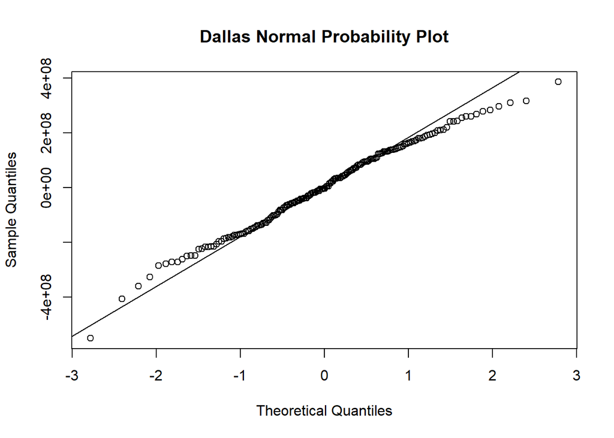

```r
qqnorm(results$Dallas$lmodel$residuals, main="Dallas Normal Probability Plot")
qqline(results$Dallas$lmodel$residuals)
```

In the above statement, results is the list produced by the by function, Dallas is a *cell* in the list containing the model and summary for Dallas, lmodel is a *cell* within Dallas, that contains the lm functions output, and $residuals is the residual vector that we’re used to seeing in the lm model output.

The second way is more flexible, and better for applying to multiple cities, but a little harder to understand:

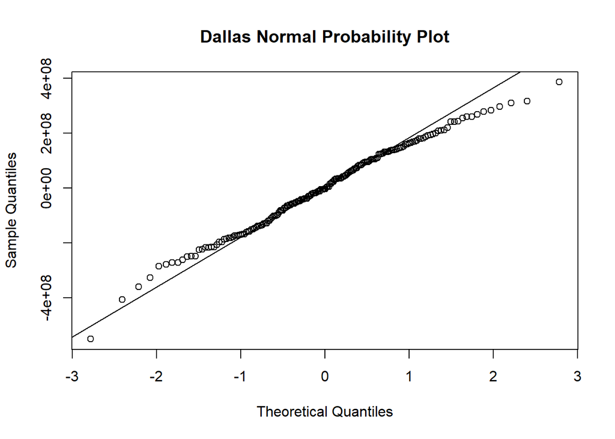

```r
city<-"Dallas"
qqnorm(results[[city]]$lmodel$residuals, main=paste(city, "Normal Probability Plot"))
qqline(results[[city]]$lmodel$residuals)
```

In the statement above, results, lmodel, and residuals are all as described previously. The difference is that I used the city name, held in a variable, to find the Dallas cell, instead of using $Dallas. This method is more flexible because it allows me to more easily loop over a subset of cities.

## Extracting a specific result

Finally, what if I wish to extract all of the adjusted R-squared values to see how the model stacks up across cities, I can use:

```r
sapply(results, function(x) {x$summary$adj.r.squared})
```

```
##               Abilene              Amarillo             Arlington
##             0.6996771             0.6393169             0.5466390
##                Austin              Bay Area              Beaumont
##             0.7240607             0.7161299             0.5958518
##       Brazoria County           Brownsville Bryan-College Station
##             0.5484700             0.6202818             0.4600603
##         Collin County        Corpus Christi                Dallas
##             0.6317005             0.6830128             0.7371361
##         Denton County               El Paso             Fort Bend
##             0.7008086             0.5990289             0.7517714
##            Fort Worth             Galveston               Garland
##             0.7981448             0.5314149             0.5327421
##             Harlingen               Houston                Irving
##             0.6786516             0.7835289             0.7243376
##             Kerrville     Killeen-Fort Hood                Laredo
##             0.6014931             0.5937862             0.5073721
##     Longview-Marshall               Lubbock                Lufkin
##             0.4470098             0.5756456             0.5931504
##               McAllen               Midland     Montgomery County
##             0.5300903             0.5818037             0.7784511
##           Nacogdoches     NE Tarrant County                Odessa
##             0.2360416             0.6531168             0.4607235
##                 Paris           Port Arthur            San Angelo
##             0.3222942             0.5816011             0.7289847
##           San Antonio            San Marcos       Sherman-Denison
##             0.7618242             0.2245941             0.6523625
##    South Padre Island         Temple-Belton             Texarkana
##             0.3582424             0.6011726             0.4294948
##                 Tyler              Victoria                  Waco
##             0.7208119             0.6579342             0.5729272
##         Wichita Falls
##             0.5155846
```

Pretty cool, right! Try to do *that* so easily in Excel!